# ‘Stress-Testing’ using *fore*SIGHT: Stochastic simulation

David McInerney, Seth Westra, Anjana Devanand, Michael Leonard, Sam Culley, Bree Bennett

14 Sep 2025

# 1. Overview

This vignette demonstrates the use of stochastic weather generators for producing perturbed climates for ‘stress-testing’ a system using *fore*SIGHT. The inverse approach (Guo et al. 2018) is used to optimize the parameters of one or more stochastic weather generators. The examples in this vignette both collate—and provide context to—information scattered in the function help files to discuss the considerations for application of *fore*SIGHT to more complex case studies and systems.

It is assumed that the reader has already read the *Introduction to climate stress testing using* fore*SIGHT* vignette, and is familiar with the basic *fore*SIGHT work flow demonstrated below:

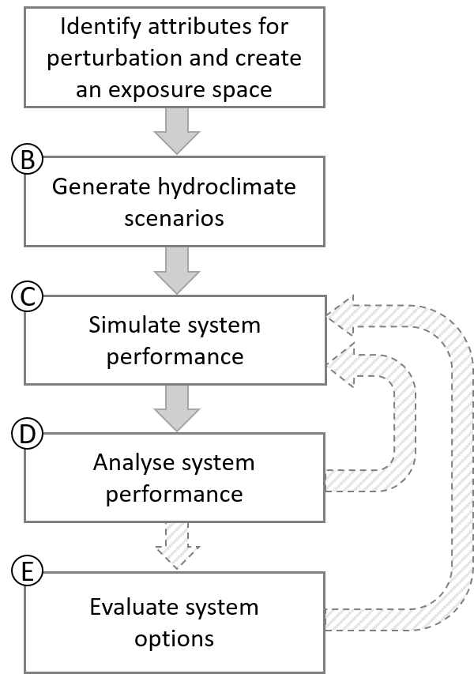

Workflow of climate ‘stress-testing’ using *fore*SIGHT

In this vignette, you’ll learn how to use *fore*SIGHT to generate and evaluate stochastic weather simulations that perturb a wide range of climate attributes. This is relevant to Steps A and B in the *fore*SIGHT workflow, with topics including:

- **Understanding attribute names**: Variables, time scales, stratification, and relevant time series statistics.
- **Creating an exposure space**: Defining perturbed, held, and tied attributes to generate realistic climate time series.
- **Selecting and configuring stochastic weather generators (SWGs)**: Choosing suitable models, generating perturbed series, and adjusting default model settings.
- **Applying post-processing routines**: Capturing climate features not represented directly by the SWGs.
- **Customizing optimization settings**: Modifying optimization settings and setting penalty weights for specific attributes.
- **Evaluating stochastic climates**: Assessing how well simulations match target attributes, capture secondary changes, and represent climate features relevant to your system model.

We begin by introducing the key concepts and showing how they are implemented in the *fore*SIGHT package. These concepts are then illustrated through a case study, which stress-tests how streamflow in Scott Creek, South Australia, responds to changes in climate attributes across multiple metrics.

# 2. Attribute naming convention

*fore*SIGHT offers a uniquely flexible capability to perturb any number of climate attributes—either individually or in combination. To support this flexibility, attribute names follow a standardized naming convention in the format: “*var*_*agg*_*strat*_*funcPars*_*op*”, where

- “*var*” is the variable name,
- “*agg*” is the aggregation period,
- “*strat*” is temporal stratification,
- “*func*” is function name (with “*Pars*” denoting additional optional parameters), and
- “*op*” is an optional operation.

For example, “P_year_all_avg” is the average yearly calculated using all the data rainfall (i.e. mean annual rainfall) and “P_day_all_P99_m” is annual mean of the 99th percentile of rainfall calculated over all days.

### 2.1. Variable names

The variable name “*var*” can be any string (that does not contain the separating character ‘_’), and could include:

- “P”: rainfall
- “Temp”: temperature
- “PET”: Potential evapotranspiration

### 2.2. Temporal stratification

The aggregation period “*agg*” can be

### 2.3. Function names (and optional parameters)

Examples of function names and parameters include:

- “tot”: total
- “P99”: 99th percentile
- “maxDSDT1”: maximum dry-spell duration (with threshold above 1mm)

A full list of attribute functions supported in *fore*SIGHT can be viewed using the helper functions `viewAttributeFuncs()`. The table below provides a summary of these functions.

*List of attribute functions available in* fore*SIGHT.*

| **Function name** | **Description** | **Options:** **Syntax** | **Options:** **Description** | **Options:** **Default** | **Typical** **variable** |
| --- | --- | --- | --- | --- | --- |
| avg | Average (mean) | - | - | - | Any |
| avgDSD | Average dryspell duration (below threshold) | avgDSDT*x* | Threshold, *x* | *x=0* | P (rainfall) |
| avgDwellTime | Average dwell time, i.e. average of periods with below median value | - | - | - | Any |
| avgWSD | Average wetspell duration | avgWSDT*x* | Threshold, *x* | *x=0* | P (rainfall) |
| cor | Lag-1 autocorrelation | - | - | - | Any |
| cv | Coefficient of variation (sdev/mean) | - | - | - | Any |
| dyWet | Average rainfall on wet days (above threshold) | dyWetT*x* | Threshold, *x* | *x=0* | P (rainfall) |
| F0 | Number of frost days (below zero) | - | - | - | Temperature |
| maxDSD | Maximum dry spell duration (below threshold) | maxDSDT*x* | Threshold, *x* | *x=0* | P (rainfall) |
| maxWSD | Maximum wet spell duration (above threshold) | maxWSDT*x* | Threshold, *x* | *x=0* | P (rainfall) |
| normP | Normalised percentile (percentile divided by mean) | normP*x* | Probability (%), *x* | None (must be specified) | Any |
| nWet | Number of wet days (above threshold) | nWetT*x* | Threshold, *x* | *x=0* | P (rainfall) |
| P | Percentile | P*x* | Probability (%), *x* | None (must be specified) | Any |
| R | Number of days above a threshold (often used for temperature) | R*x* | Threshold, *x* | None (must be specified) | Temperature |
| rng | Inter-quantile range | rng*x* | Probability (%), *x* | *x=90* | Temperature |
| seasRatio | Seasonality ratio (ratio of seasonal to total rainfall) | seasRatio*Mon1Mon2* | Start and end months of season, *Mon1, Mon2* | *Mon1=Mar* *Mon2=Aug* | P (rainfall) |
| tot | Total | - | - | - | P (rainfall) |
| WDcor | Lag-1 autocorrelation for wet days | - | - | - | P (rainfall) |
| wettest6monPeakDay | Day of year corresponding to the wettest 6 months | - | - | - | P (rainfall) |
| wettest6monSeasRatio | Ratio of wet season to dry season rainfall, based on wettest6monPeakDay | - | - | - | P (rainfall) |

*fore*SIGHT also allows users to define their own custom functions. The names of these functions must have the format “func_customName”, where “customName” is the custom attribute function. These functions must have the argument “data”, which represents the time series of climate data. For example,

```r
func_happyDays <- function(data){
  return(length(which((data>25)&(data<30))))
}
```

can be used in the attribute “Temp_day_all_happyDays_m” for calculating the average number of days each year with temperatures between 25<sup>o</sup>C and 30<sup>o</sup>C.

### 2.4. Operator name

The operator name is optional, and currently is limited to “m”: mean value of metric calculated over all years. Often “*op*” will be left empty.

The use of the operator “`m`” is a subtle, but important, choice. It determines whether the metric is calculated once using all the data (when operator is not specified), or whether the metric is calculated for each year, and then averaged over all years (when operator specified as “`m`”). For example, “`P_day_all_P99`” refers to the 99th percentile of daily rainfall calculated over all days, while “`P_day_all_P99_m`” would be the mean value of the 99th percentile of daily rainfall from each year.

This distinction becomes particularly important when comparing attributes across datasets of different lengths. For example, calculating the number of wet days without using `"m"` can be misleading, as longer time series will naturally accumulate more wet days. Including `"m"` ensures comparability by standardising the metric to an annual average.

The flexibility of attribute names can lead to some equivalence in attributes. E.g. `"P_day_all_tot_m"` is mean annual value of the total of daily rainfall. This is equivalent to `"P_year_all_avg"` - the average of the yearly rainfall.

It is noted that attributes are specified either as a fractional change relative to historical levels (and thus do not have units), or they are specified using the metric system.

### 2.5. Viewing attribute definitions and calculating values

The definition of climate attributes used in *fore*SIGHT can be viewed using the helper function `viewAttributeDef()` available in the package.

```r
viewAttributeDef("P_day_all_tot_m")
```

```
#> [1] "Mean annual rainfall"
```

Can calculate attributes using `calculateAttributes()`

```r
data("tankDat")
calculateAttributes(climateData=tank_obs,attSel=c('P_day_all_tot_m','P_day_all_P99'))
```

```
#> P_day_all_tot_m   P_day_all_P99
#>         449.930          17.148
```

### 2.6. Multivariable attributes

*fore*SIGHT also supports the calculation of multivariable climate attributes, which are based on the interaction between two time series (e.g., precipitation, P, and potential evapotranspiration, PET ).

Multivariable attributes follow the naming convention “mv.*var1*.*var2*_*agg*_*strat*_*func*_*op*”, where

- “*var1*” and “*var2*” are time series of climate variables
- “*func*” is the multivariable function name
- Other components (“*agg*”, “*strat*”, “*op*”) are defined as per single-variable attributes

Examples include

- `"mv.P.Temp_day_all_cor"` which calculates correlation between daily precipitation and temperature
- `"mv.P.PET_day_MAM_avgWetDay"` which is average value of PET on wet days (when P>0) between March and May.

Currently, a limited number of built-in multivariable attributes are available in *fore*SIGHT, as listed in the table below.

*List of multivariable attribute functions*

| Function name | Description | Typical variable 1 | Typical variable 2 |
| --- | --- | --- | --- |
| avgDryDay | Average value of variable 2 on dry days (assuming P is variable 1) | P (rainfall) | Temp, PET |
| avgWetDay | Average value of variable 2 on dry days (assuming P is variable 1) | P (rainfall) | Temp, PET |
| cor | Correlation between variables | P (rainfall) | Temp, PET |
| cvDryDay | Coefficient of variation of variable 2 on dry days (assuming P is variable 1) | P (rainfall) | Temp, PET |
| cvWetDay | Coefficient of variation of variable 2 on wet days (assuming P is variable 1) | P (rainfall) | Temp, PET |

Users can also define their own custom multivariable functions. For an example of the input and output requirements of these functions, see the built-in function `mvFunc_cor()`.

```r
mvFunc_cor
```

```
#> function (data.1, data.2)
#> {
#>     return(stats::cor(data.1, data.2, use = "pairwise.complete.obs"))
#> }
#> <bytecode: 0x0000026ae737bce0>
#> <environment: namespace:foreSIGHT>
```

## 3. Creating the exposure space (Step A)

The `createExpSpace()` function is used to define the **exposure space**—a set of perturbations applied to selected climate attributes. The general process for specifying perturbed attributes, along with the sampling strategy and bounds, follows the same principles outlined in the *Introduction to climate stress testing using* fore*SIGHT* vignette

To generate **realistic climate time series**, it is often necessary not only to perturb key attributes but also to specify **held** and **tied** attributes. As a rule of thumb, the total number of **target attributes** (including perturbed, held, and tied attributes) should be at least as large as the number of fitted parameters in the stochastic weather generator (SWG).

Selecting **held** and **tied** attributes is often a challenging task. It requires expert judgment to determine which climate changes are plausible, and typically involves an iterative process of evaluation and refinement to ensure the generated scenarios are both realistic and relevant.

## 3.1. Perturbed attributes

As shown in the *Quick Start Guide*, the **scaling approach** for generating perturbed climates allows only a limited set of attributes to be explicitly modified—typically:

- Annual averages and totals (e.g., `P_day_all_tot_m`, `Temp_day_all_avg`)
- Seasonality ratios (e.g., `P_day_all_seasRatioMarAug`)

By contrast, **stochastic simulation** enables a much broader set of attributes to be perturbed. The actual attributes that can be modified depend on the capabilities of the specific stochastic generator being used (see Sections 4.3.1 and 4.3.2 for more details).

## 3.2. Held attributes

To maintain realistic climate behavior, certain attributes can be **held constant**, typically at their historical values. This is especially useful to prevent perturbations from producing unrealistic extremes or seasonal patterns.

Held attributes are specified using the `attHold` argument. For example:

`attHold <- c("P_day_all_P99", "P_day_all_maxWSD_m", "P_day_all_seasRatioJunAug")`

In this case, these three attributes are held at reference levels. The attributes 99th percentile rainfall, maximum length of the wet spells are held at reference levels so that the perturbations do not result in unrealistic extreme rainfall events. In addition, the attribute “P_day_all_seasRatioJunAug” is held at reference levels so that the seasonal cycle of the generated data is realistic.

There are also mechanisms to ensure to preferentially matching the desired values of some attributes during time series generation (as described in Section 4.3.4).

## 3.3. Tied attributes

Attributes can also be **tied** together, meaning they share the same perturbation. This is useful when certain attributes are logically or physically linked.

For example, to ensure that **JJA rainfall totals** (`P_day_JJA_tot_m`) change in line with **annual rainfall totals** (`P_day_all_tot_m`), use:

`attTied <- list(P_day_all_tot_m = c("P_day_JJA_tot_m"))`

In some situations, it may be beneficial to tie **attributes for each season** to their equivalent derived from the full time series. For example, tying seasonal 99th percentiles to the overall 99th percentile:

```r
attTied <- setSeasonalTiedAttributes(attSel = "P_day_all_P99")
attTied
```

```
#> $P_day_all_P99
#> [1] "P_day_DJF_P99" "P_day_MAM_P99" "P_day_JJA_P99" "P_day_SON_P99"
```

This will tie `P_day_DJF_P99` , `P_day_MAM_P9` , `P_day_JJA_P99 and P_day_SON_P99` to the attribute `P_day_all_P99`, ensuring consistent changes across seasons.

## 3.4 Example: Creating an exposure space

This example demonstrates the use of `createExpSpace()` to define a climate exposure space, including **perturbed**, **held**, and **tied** attributes. As noted earlier, selecting held and tied attributes requires expert judgment, particularly in anticipating how different attributes are likely to co-vary with those being explicitly perturbed. The process is often iterative.

*Perturbed Attributes*

These two attributes are perturbed over a 5×5 regular grid.

*Held Attributes*

To maintain realism and constrain the stochastic generation process, the following attributes are held constant (at historical levels):

- **Mean annual rainfall** `"P_day_all_tot_m"`
- **Seasonal rainfall**: `"P_day_DJF_tot_m"`, `"P_day_JJA_tot_m"`, `"P_day_SON_tot_m"`
- **Number of wet days** (annual and seasonal): `"P_day_all_nWet_m"`, `"P_day_DJF_nWet_m"`, `"P_day_MAM_nWet_m"`, `"P_day_JJA_nWet_m"`, `"P_day_SON_nWet_m"`
- **Average dry-spell duration** (annual and seasonal): e.g. `"P_day_all_avgDSD"`, `"P_day_DJF_avgDSD"`, etc.

*Tied Attributes*

To ensure consistent changes across related attributes, the following **tied relationships** are defined:

```r
############################################################################
# create exposure space

attPerturbType <- "regGrid"
# perturb seasonality and 99% rainfall
attPerturb <- c('P_day_all_seasRatioMarMay','P_day_all_P99')
# consider a 5x5 grid
attPerturbSamp <- c(5,5)
attPerturbMin <- c(0.7,1.)
attPerturbMax <- c(1.3,1.3)
# will hold a number of attributes to historical values
attHold <- c('P_day_all_tot_m',
            'P_day_DJF_tot_m','P_day_JJA_tot_m','P_day_SON_tot_m',
            'P_day_all_nWet_m',
            'P_day_DJF_nWet_m','P_day_MAM_nWet_m',
            'P_day_JJA_nWet_m','P_day_SON_nWet_m',
            'P_day_all_avgDSD',
            'P_day_DJF_avgDSD','P_day_MAM_avgDSD',
            'P_day_JJA_avgDSD','P_day_SON_avgDSD'
            )
# tied attributes
# note: normP = P99/avg rainfall. normP in each season is tied to P99
attTied <- list(P_day_all_P99=c('P_day_DJF_normP99',
                               'P_day_MAM_normP99',
                               'P_day_JJA_normP99',
                               'P_day_SON_normP99'),
              P_day_all_seasRatioMarMay=c('P_day_MAM_tot_m')) # MAM rain tied to seasRatioMarMay

expSpace <- createExpSpace(attPerturb = attPerturb,
                          attPerturbSamp = attPerturbSamp,
                          attPerturbMin = attPerturbMin,
                          attPerturbMax = attPerturbMax,
                          attPerturbType = attPerturbType,
                          attHold = attHold,
                          attTied = attTied)
```

**Note:** The selection of **perturbed**, **held**, and **tied** attributes in this example creates some inherent conflicts, meaning that not all target values can be perfectly matched.

In such cases, the optimization process will aim to find the **best compromise** across the specified targets. The **relative importance** of each attribute can be adjusted using **attribute weights**, as described in Section 4.3.4.